# Chapter 8: Non-Linear Regression with `scikit-learn`

**Goals**

- Learn the basics of artificial neural networks
- Learn about data preparation and preprocessing
- Understand why a test-train split is important
- Fit and evaluate a multilayer perceptron with `scikit-learn`

## 8.1 Introduction

### 8.1.1. Recap and Agenda

In the last lecture, we obtained a **M**ultiple **L**inear **R**egression (MLR) model that takes whole UV/vis spectra $A(\lambda)$ as input and predicts the corresponding caffeine concentration $c$ based on a **linear** dependence $c(A)$. Additionally, we imported UV/vis data from an extraction experiment and converted this into an extraction kinetic $c(t)$ shown in Figure 1. As you can see, this functional dependence $c(t)$ is clearly **non-linear**.

[figure not shown]

**Figure 1:** *Caffein concentration $c$ over extraction time $t$*.

Now, let us assume that excessive and validated measurements of caffein concentration $c$ vs. extraction time $t$ are at our disposal. For this dataset, experimental factors like grain size and temperature are constant. We can use this large data set to train a data-driven, non-linear regression model. In addition, this lecture introduces basic concepts of **regression model diagnostics** that are required to validate that the trained model is able to accurately **interpolate** on *new* and *unseen* data. In the process, we will perform a so called **train-test-split**.

### 8.1.2 Data Import

The measured data is provided to us by our colleague ***Mr. Pug*** who saved the numerical data as numpy arrays in the `.npy` file format.

In the `./data/exchange_mr.pug/` folder, we find the following `.npy` files:

| filename | Description |
| --- | --- |
| `2023_extraction_kinetics_T92_d50-2mm_t_data` | Array of extraction time |
| `2023_extraction_kinetics_T92_d50-2mm_c_data` | Array of concentration data |

In total, Mr. Pug measured $N=400$ corresponding data pairs of $t$ and $c$. Let's import this data with `numpy.load()` and visualize the data in a scatter-plot.

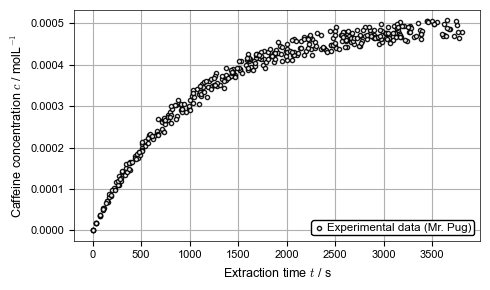

```python
import numpy as np
import matplotlib.pyplot as plt
import mod.my_plotter as mp
mp.init_plot(scl_a4=1, page_lnewdth_cm=10, mrksze=3)

# Load external data from the data folder.
t_exp = np.load('./data/exchange_mr.pug/2023_extraction_kinetics_T92_d50-2mm_t_data.npy', allow_pickle=True)
c_exp = np.load('./data/exchange_mr.pug/2023_extraction_kinetics_T92_d50-2mm_c_data.npy', allow_pickle=True)

# Plot the data
fig, ax = plt.subplots(figsize=(5,3))
ax.scatter(t_exp, c_exp, label=r'Experimental data (Mr. Pug)', edgecolors='k', color='w', alpha=0.9)
ax.set_xlabel('Extraction time $t$ / s')
ax.set_ylabel('Caffeine concentration $c$ / molL$^{-1}$')
ax.legend(loc='lower right', fontsize='small', framealpha=1, ncol=1, labelspacing = 0.6)
ax.grid(True)
plt.tight_layout()
```

### 8.1.3 Discussion of the Functional Relationship and Modeling Strategy

We can see that the curve resembles a limited growth. Intuitively, we try model this dependence with the equation

$$c = L - ( L - c_{0})\;exp(-k t) ,$$

where $L$ is the upper limit, $c_{0}$ the concentration at extraction time $t=0$ and $k$ a growth constant. At $t=0$, the caffeine concentration is zero, meaning $c_{0}=0$, further simplifying this expression. To check whether this model is a good fit for our data will be part of today's homework.

Right now, we'll go for a different approach. Besides easy-to-understand linear models, the `scikit-learn` library contains more generalized models aiming at finding a functional dependence between multiple factors which can be more **complex**, seemingly random or simply **non-linear**. In this example, we clearly see the influence of $t$ on our concentration $c$. Nature, however, is well-known for producing more complex dependencies that cannot be easily digested or analyzed with the naked eye. This is especially true, when there are multiple factors and outputs! Therefore, it is good to know that there are algorithms out there, which tackle these problems and are e.g. able to tell you if there is a dog or a cat in any given picture (try finding a functional relationship for that!). One commonly applied algorithm or model architecture is the **Artificial Neural Network** (ANN). Obviously, we cannot explain everything there is to know about ANNs in this lecture. However, we will look at how they can be applied using the `scikit-learn` package. This allows us to model the extraction kinetic **completely data-driven**, i.e. without assuming any form of functional relationship beforehand.

### 8.1.4 Artificial Neural Networks: Basic Structure of a Multi Layer Perceptron (MLP)

As the name suggest, ANN are based on (or at least similar to) biological neural networks. In simple terms, a single neuron is a cell that has the purpose of processing and transporting information. Electrical signals (inputs) are accepted via it's dendrites and collected inside the cell body. The output signal is processed in the axon before being given to connected neurons. This behavior can be represented mathematically as shown in Fig. 2: Input variables $x_i$ are multiplied with specific weights $w_i$ and *collected*, i.e. summed up. The intermediate $h$ is further processed by a so-called activation function that scales the value and decides whether the signal is passed or the neuron stays *inactive*. The final result $y$ is passed on as output variable.

Such neurons can be combined to a neural network, where the outputs of certain neurons serve as input for other neurons. Depending on the structure and type of connection between the neurons, various model architectures can be distinguished. This lecture and Fig. 2 covers the so-called *Multilayer Perceptron* (MLP): It is a **feedforward** ANN, i.e. information is only transferred from left to right (input $\rightarrow$ output). A MLP consists of at least 3 layers: The input layer, where multiple input arguments $x_i$ are accepted, at least one hidden layer used for data transformation and an output layer, where the outputs $y_i$ are presented. For an increasing number of hidden layers, the model is commonly called a deep neural network (deep learning). Additionally, MLPs are fully connected meaning that each neuron of layer $j$ passes its output to each neuron in layer $j+1$.

[figure not shown]

**Figure 2:** *Basic structure of a biological and mathematical neuron as well as multilayer perceptron (MLP).*

It is mind-blowing that such a simple mathematical structure (multiplying by $w$, summation and application of a simple activation function) is able to predict literally any functional relationship. Given of course that you combine enough of them and train them properly. Speaking of training: The unknown parameters of a MLP are its weights $w_{i,j}$. During training, these weights are **optimized** until the difference between predicted outputs $y_{\mathrm{pred}}$ and the training data $y_{\mathrm{train}}$ is minimal. This is literally, the same concept as fitting a straight line, like we did in chapter 6! Only with more unknown parameters.

We will leave it here for now, just know that there is so much more to learn about ANNs and their training. [This video series](https://www.youtube.com/watch?v=aircAruvnKk&list=PLZHQObOWTQDNU6R1_67000Dx_ZCJB-3pi) by *3Blue1Brown* is highly recommended if you want to learn more about neural networks. It will teach you the basic notations and interesting use cases.

## 8.2 Data Preparation

### 8.2.1 Data Structure in Mathematical, `scikit-learn` Language

> ***Note:*** When working with data with only a **single feature** ($J=1$ as e.g. in this case the extraction time) your input data needs to fullfil the shape criterion `(O, 1)` ($O$ not 0!). In case your data has the shape `(O,)` (also a valid shape for a 1D array) you need to **reshape** the array using the `.reshape()` method.

```python
# Reshape our imported data so we can use it with the scikit-learn models
t_exp = t_exp.reshape(-1, 1)
c_exp = c_exp.reshape(-1, 1)
```

### 8.2.2 Preprocessing Data: Normalization and Standardization

Data is the key resource in any machine learning task. Therefore, the top priority should always be to obtain **high quality** data that covers the entire parameter space of interest. This starts in the lab and contains both the planning and execution of your experiments! As mentioned various times, you should always visualize your data if possible to detect and remove/repeat **outliers**, as they can drastically limit your model performance. Note that there are statistical tools (in which we will not go into detail here) that make outlier detection more objective.

Now you have your high-quality target array $(O\times P)$ and samples matrix $(O\times J)$ and are eager to train some models. But behold, there are some preprocessing steps you need to take care of first. Look at the MLP in Fig. 2 and imagine the following scenario: You want to predict your marathon race time $y_0$ (in min, somewhere in the range of $[120,300]$), based on your average weekly run volume during training $x_0$ (in km, somewhere in the range of $[0,200]$) and some running efficiency parameter $x_1$ (in J/kg/km, somewhere in the range of $[10^{-4},10^{-3}]$). If both input parameters are somewhat *"equally relevant"*, the weights $w_{i,0}^{(1)}$ and $w_{i,1}^{(1)}$ differ strongly in their numeric value. Remember: Each neuron sums up it's weighted inputs. If the numeric values of the inputs $x_0$ and $x_1$ are on different orders of magnitude, the weights have to *"compensate"* for that. In general, this is possible and will work, however this introduces some numerical problems during the optimization procedure. A better way of doing this is **scaling the inputs** so that they are comparable. In this example, you could e.g. input $x_0$ not in km but in Mm (mega-meter, yeah!) to bring the numeric values closer together. After all, the unit shouldn't be relevant for the prediction!

There are two general approaches for scaling the samples matrix more objectively that don't require any closer investigation of the physics behind the inputs: During **normalization**, your inputs $x_i$ are scaled to the range $[0,1]$ by applying

$$ \tilde{x_i}=\frac{x_i-x_{i,\mathrm{min}}}{x_{i,\mathrm{max}}-x_{i,\mathrm{min}}} . $$

During **standardization**, your inputs $x_i$ are transformed according to

$$ \tilde{x_i}=\frac{x_i-\mu_i}{\sigma_i} ,$$

so that their mean value is $\mu=0$ and their standard deviation is $\sigma=1$. Although considered appropriate in most cases, standardization assumes a gaussian distribution of your samples and might not be the best choice for your data. Sadly, there is no *superior* preprocessing strategy, but it always depends on your data. You simply have to test different preprocessing routes and see which ones perform best. But make a good habit of always using either normalization or standardization for your models!

You guessed it: We do not have to do this manually, as both preprocessing strategies (and more) are included in the [`sklearn.preprocessing()`](https://scikit-learn.org/stable/modules/classes.html#module-sklearn.preprocessing) module. As you will see in the example below, you can fit and apply so-called *transformers* to your data. For normalization use an instance of the [`MinMaxScaler`](https://scikit-learn.org/stable/modules/generated/sklearn.preprocessing.MinMaxScaler.html#sklearn.preprocessing.MinMaxScaler) class, for standardization use an instance of the [`StandardScaler`](https://scikit-learn.org/stable/modules/generated/sklearn.preprocessing.StandardScaler.html#sklearn.preprocessing.StandardScaler) class:

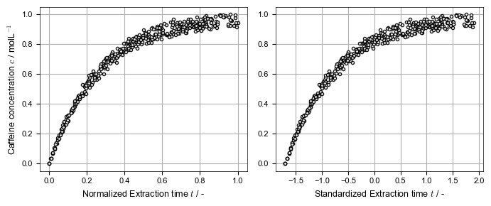

```python
from sklearn.preprocessing import MinMaxScaler, StandardScaler

# Initialize two transformers. One for normalization, one for standardization
norm_transformer = MinMaxScaler(feature_range=(0,1)) # feature_range is optional! (0,1) is the default.
std_transformer = StandardScaler()
# Also transform c data (use normalization only)
c_norm_transformer = MinMaxScaler(feature_range=(0,1))

# Fit both transformer instances to your data
norm_transformer.fit(t_exp)
std_transformer.fit(t_exp)
c_norm_transformer.fit(c_exp)

# Actually transform your data
t_exp_norm = norm_transformer.transform(t_exp)
t_exp_std = std_transformer.transform(t_exp)
c_exp_norm = c_norm_transformer.transform(c_exp)

# Plot the results
fig, ax = plt.subplots(1,2,figsize=(7,3))

# Single measurements
ax[0].scatter(t_exp_norm, c_exp_norm, edgecolors='k', color='w', alpha=0.9)
ax[0].set_xlabel('Normalized Extraction time $t$ / -')
ax[0].set_ylabel('Caffeine concentration $c$ / molL$^{-1}$')
ax[0].grid(True)
ax[1].scatter(t_exp_std, c_exp_norm, edgecolors='k', color='w', alpha=0.9)
ax[1].set_xlabel('Standardized Extraction time $t$ / -')
ax[1].grid(True)
plt.tight_layout()
```

### 8.2.3 Test-Train Split

As you definitely worked through the homework of chapter 7, we do not need to talk about test-train splitting, right? Right? . Well in case you missed it, let's do it anyway: The general idea of a **test-train split** is that we *reserve*, i.e. hold back data points during training, so that we can later test the predictions of our model on *unseen* inputs. This makes the evaluation of model performance more objective and helps us identify so-called [overfitting](https://en.wikipedia.org/wiki/Overfitting). Vividly, an overfit model has too many degrees of freedom, which makes it easily adjustable to any data set, but often leads to *"extreme"* behavior during interpolation. Look at the example in Fig. 3: There are 10 training (green) and 10 test (red) data points. We fit both a polynomial of degree 10 (left) and a polynomial of degree 1, i.e. a linear regression (right) to the **training data** and don't use the **test data** for anything (yet). When you compare the $\mathrm{RMSE}_{\mathrm{train}}$ on the train data you'll see that the left model is *better* in the sense that it's prediction error is lower. But just look at both models: Who in their right mind would wholeheartedly say that the left model is a better representation of the overall data? This is where the test data comes in: Comparing the $\mathrm{RMSE}_{\mathrm{test}}$ reveals that although the right model might be off a bit more on the training points, it represents the overall data better. You could say that it is better at interpolation. Test-train splitting is especially important for model architectures that are prone to overfitting because they have a lot of internal parameters, like our MLP.

[figure not shown]

**Figure 3:** *Visualization of overfitting.*

As usual, you can do this by hand (don't mix up the indices!) or apply a built in method. In our case, we will use [`sklearn.model_selection.train_test_split( )`](https://scikit-learn.org/stable/modules/generated/sklearn.model_selection.train_test_split.html), that takes an arbitrary amount of arrays and splits them into train and test arrays, while keeping the indices in sync. The argument `train_size` defines the split ratio (between 0 and 1) and by supplying `random_state`, you can make your splits reproducible.

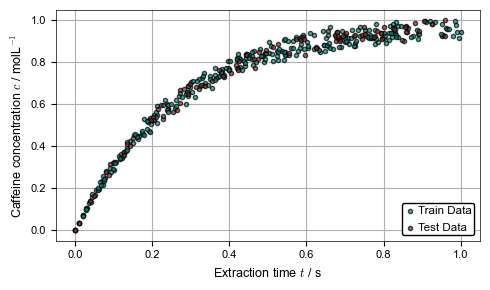

```python
from sklearn.model_selection import train_test_split

# Split the data. Use 80% for training and 20% for testing
# Let's only continue with the normalized data
t_exp_train, t_exp_test, c_exp_train, c_exp_test = \
    train_test_split(t_exp_norm, c_exp_norm, test_size=0.2, random_state=42)

# Plot the data
fig, ax = plt.subplots(figsize=(5,3))
ax.scatter(t_exp_train, c_exp_train, label='Train Data', edgecolors='k', color=mp.green, alpha=0.7)
ax.scatter(t_exp_test, c_exp_test, label='Test Data', edgecolors='k', color=mp.red, alpha=0.7)
ax.set_xlabel('Extraction time $t$ / s')
ax.set_ylabel('Caffeine concentration $c$ / molL$^{-1}$')
ax.legend(loc='lower right', fontsize='small', framealpha=1, ncol=1, labelspacing = 0.6)
ax.grid(True)
plt.tight_layout()
```

### 8.2.4 A Note on Hyper-Parameter Optimization

Before we actually train the MLP, we have to define certain **hyper-parameters** of the model architecture. These include the number of neurons and the number of layers. Choosing these parameters influences the degree of freedom the model has and ultimately also the likelihood of obtaining an overfit model. They also drastically influence model performance. However, there is no way of knowing beforehand what a good hyper-parameter setting might be, as it is highly problem and data dependent. As always, you can simply *try*, i.e. repeatedly train models with varying hyper-parameters and *see* which work well. Just note that there are certain strategies of *optimizing* these hyper-parameters before training the actual model. For now, we will not go down this rabbit-hole and simply guess or set the required parameters.

## 8.3 Training and Model Evaluation

### 8.3.1. Training of the MLP

After all this pre-processing, it is finally time to fit a non-linear regression model with the **model class** [`sklearn.neural_network.MLPRegressor(..)`](https://scikit-learn.org/stable/modules/generated/sklearn.neural_network.MLPRegressor.html#sklearn.neural_network.MLPRegressor) provided by `sklearn`. Let's have a look at the most important (hyper-)parameters and methods:

**Parameters:**

- `hidden_layer_sizes=(100,)`: Structure of the *hidden layers* of our MLP as `tuple`. `len(hidden_layer_sizes)` defines the number of hidden layers and `hidden_layer_sizes[i]` defines the number of neurons in layer `i`. For example, `(10,2,1)` corresponds to 3 hidden layers with 10, 2 and 1 neurons respectively.
- `activation='relu'`: Activation function of each neuron as `str`. Viable options are `{'identity', 'logistic', 'tanh', 'relu'}`.
- `solver='adam'`: Solver for optimization of the weights.
- `alpha=0.0001`: Regularization factor to tackle over-fitting of the model by punishing large weights.
- `random_state=1`: Make initialization of the weights reproducible.
- `max_iter=200`: Maximum number of iterations
- `tol=1e-4`: Stopping tolerance of the training procedure.

**Methods:**

- `fit(X,y)`: Fit the model to samples matrix `X` and target array `y`.
- `predict(X)`: Predict the target array for a given samples matrix.

As you can tell, working with this model class is nearly identical to the linear regression model of chapter 7. That's the beauty of `sklearn`! Let's fit the MLP model and visualize its predictions.

Now is a good time to play with the hyper parameters of the MLP: Change the number and sizes of the hidden layer and try different activation functions. Although the functional relationship is rather easy, the MLP is only able to predict it if the hyper-parameters are chosen correctly!

```
It took 182 iterations to fit the MLP model!
```

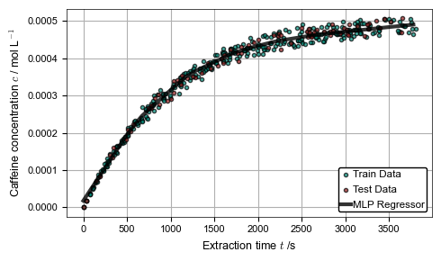

```python
# Import model class
from sklearn.neural_network import MLPRegressor

# Create an instance variable for our MLP model. "Hand pick" the hyper parameters
mlp_model = MLPRegressor(hidden_layer_sizes=(100,100), activation='relu', solver='adam',
                          alpha=0.001, random_state=1, max_iter=500, tol=1e-6)

# Fit the MLP model to our training data
mlp_model.fit(t_exp_train, c_exp_train)
print('It took', mlp_model.n_iter_, 'iterations to fit the MLP model!')

# Export the MLP model
np.save('export/mlp_c_t.npy', {'mlp':mlp_model, 'c_trans':c_norm_transformer, 't_trans':norm_transformer})

# Define a t-array for a continuous plot of the predictions. Don't forget to apply the scaler!
t_plot = np.linspace(0,63*60,1000).reshape(-1, 1)
t_plot = norm_transformer.transform(t_plot)

# Make predictions
c_plot = mlp_model.predict(t_plot).reshape(-1, 1)

# Plot (Rescale values to the physical magnitude)
fig, ax = plt.subplots(figsize=(5,3))
ax.scatter(norm_transformer.inverse_transform(t_exp_train),
           c_norm_transformer.inverse_transform(c_exp_train),
           edgecolors='k', color=mp.green, alpha=0.7, label='Train Data')
ax.scatter(norm_transformer.inverse_transform(t_exp_test),
           c_norm_transformer.inverse_transform(c_exp_test),
           edgecolors='k', color=mp.red, alpha=0.7, label='Test Data')
ax.plot(norm_transformer.inverse_transform(t_plot),
        c_norm_transformer.inverse_transform(c_plot),
        color=mp.black, linewidth=3, label='MLP Regressor', alpha=0.8)

ax.set_xlabel('Extraction time $t$ /s')
ax.set_ylabel('Caffeine concentration $c$ / mol L$^{-1}$')
ax.legend(loc='lower right', fontsize='small', framealpha=1, ncol=1, labelspacing = 0.6)
ax.grid(True)
plt.tight_layout()
```

### 8.3.2. Model Evaluation of the MLP

Remember that we reserved some data to quantify model performance on *unseen* data? We have already done this *by hand* during last weeks homework. However, `sklearn` provides a variety of ready-to-use metrics and scores that are [listed here](https://scikit-learn.org/stable/modules/model_evaluation.html). The general syntax is `sklearn.metrics.METRIC(y_true, y_pred)` as is shown in the example below:

```python
# Import the metrics of choice
from sklearn.metrics import mean_absolute_error, mean_squared_error

# Use the fitted model to predict unseen concentration values
c_pred = mlp_model.predict(t_exp_test).reshape(-1,1)

# For ROOT mean squared error set squared to False
# Again, we have to reset the scaling to "physical" dimensions
rmse = mean_squared_error(c_norm_transformer.inverse_transform(c_exp_test),
                          c_norm_transformer.inverse_transform(c_pred), squared=False)
mae = mean_absolute_error(c_norm_transformer.inverse_transform(c_exp_test),
                          c_norm_transformer.inverse_transform(c_pred))

print(f'The RMSE of our MLP model on the TEST data is {rmse:.3e}')
print(f'The MAE of our MLP model on the TEST data is {mae:.3e}')
```

```
The RMSE of our MLP model on the TEST data is 1.338e-05
The MAE of our MLP model on the TEST data is 1.156e-05
```

## 8.4 Final Notes

### 8.4.1 Artificial Intelligence and Machine Learning

[figure not shown]

The term artificial intelligence (AI) and machine learning (ML) are all around us in today's life. In some cases they are used as synonyms or even competing technologies. Both is wrong, so let's try to clear this up:

- AI is a **general concept** that describes the ability of machines to behave intelligently. This includes learning facts, processing language, seeing, moving and being creative.
- ML is a **set of tools** with which machines acquire intelligence, i.e. learn.

So, ML is a sub-field and an important part of AI but both buzzwords refer to very different things! [Here](https://youtu.be/4RixMPF4xis?si=8mX4vRNpyyyEhdOp) is a nice little video on this.

To bring this into context with chapter 7 and chapter 8: We investigated one approach (there are more!) of machine learning, called **supervised learning**. Here, a mathematical model is built from a data set that contains both the inputs and the desired outputs. Further, we only looked at **regression** tasks that predict continuous output variables, in contrast to discrete outputs predicted by classification. By this definition, every model that is *fit* to data is a form of machine learning, no matter whether it is a multi-layered neural network or a simple straight line.

### 8.4.2 General Notes

1. It's quite funny that I wrote close to an entire book full of information, but the actual model training in Python is done in just a couple lines of code. However, this emphasizes a certain threat: Blindly applying `sklearn` methods without **understanding** what the actual model and its parameters do is like gambling: Sometimes you'll win, sometimes you'll lose, but you can never *control* the outcome.  
   Nevertheless, at a certain point there will always be some *trial-and-error* involved, as you cannot know the best suited preprocessing strategy or hyper-parameters beforehand.
2. We used `sklearn` in this lecture as it easy to learn and fits well into the progression from chapter 7. However, the neural networks you are able to build and train are strongly limited*. The two most-used python packages for machine learning are [PyTorch](https://pytorch.org/) and [TensorFlow](https://www.tensorflow.org/).
3. Today we trained a rather large neural network to predict the outcome of a simple and observable dynamic (limited growth). The message of todays lecture is **not** to do everything with neural networks. Today's homework will make this clear. Remember, just because you *can* doesn't mean you *should*.

<sub>*As an example: `MLPRegressor( )` can only take a single activation function, although it might be beneficial to use different ones along the layers.</sub>